[figure not shown]

[figure not shown]

[figure not shown]

# Indlæsning af data

Vi betragter data fra kompendiets Eksempel 6.1: hormonbehandling af stude

Indlæs data

```r
steers <- read.table(file = "../data/steers.txt", header = T)
```

Datasættet består af 16 datalinjer og 3variable.

```r
names(steers)
```

```
[1] "treat" "x"     "y"
```

```r
head(steers)
```

```
  treat   x    y
1     1 560 1330
2     2 440 1280
3     3 530 1290
4     4 690 1340
5     1 470 1320
6     2 440 1270
```

Variablen **treat** repræsenterer 4 forskellige hormonbehandlinger og bør indgå i analyserne som en faktor

```r
steers$treat <- factor(steers$treat)
```

Variablen **y** angiver vægt af nyrefedt (i g) efter forsøgsperioden. Desuden er studenes vægt (i kg) før behandlingen registreret i variablen **x**.

# Visualisering af data

### Standard grafik - kode

```r
par(cex.main = 1.25, cex.lab = 1.25, cex.axis = 1.25)
plot(steers$x, steers$y, col = as.numeric(steers$treat), pch = as.numeric(steers$treat)
     , cex = 2
     , xlab= "Initial weight (kg)"
     , ylab= "Weight of kidney fat (g)")
legend(550, 1280, legend = paste("Treat=", 1:4, sep = ""), pch = 1:4, col = 1:4, cex = 1.15)
```

### Standard grafik - plot

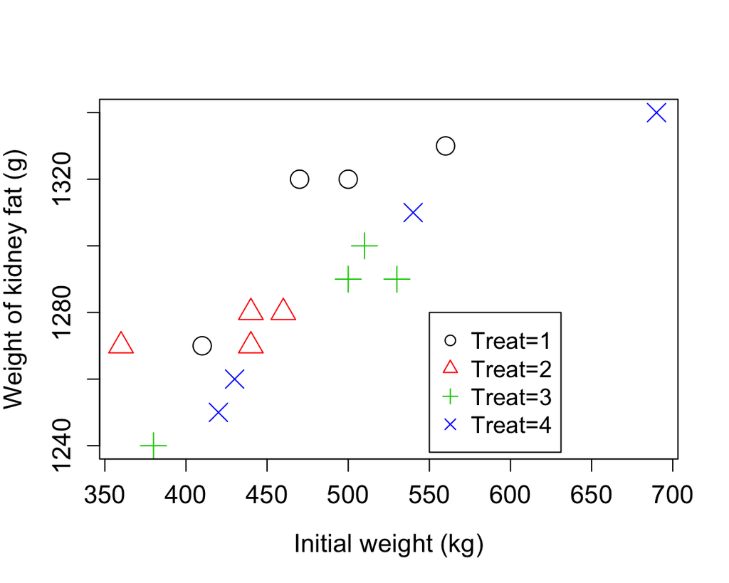

### ggplot - kode

Moderne grafik (kræver installation af R pakken **ggplot2**)

```r
library(ggplot2)
ggplot(data = steers) + geom_point(mapping = aes(x = x, y = y, color = treat), size = 5) + xlab("Initial weight (kg)") + ylab("Weight of kidney fat (g)")
```

### ggplot - plot

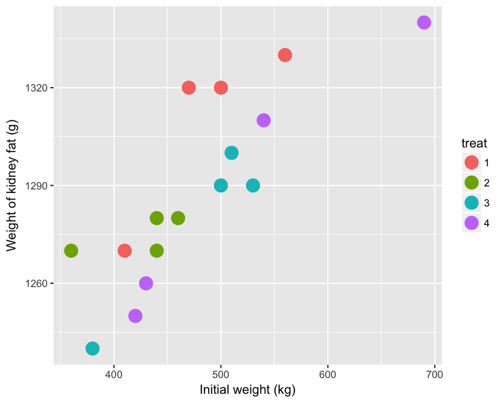

### box-plot

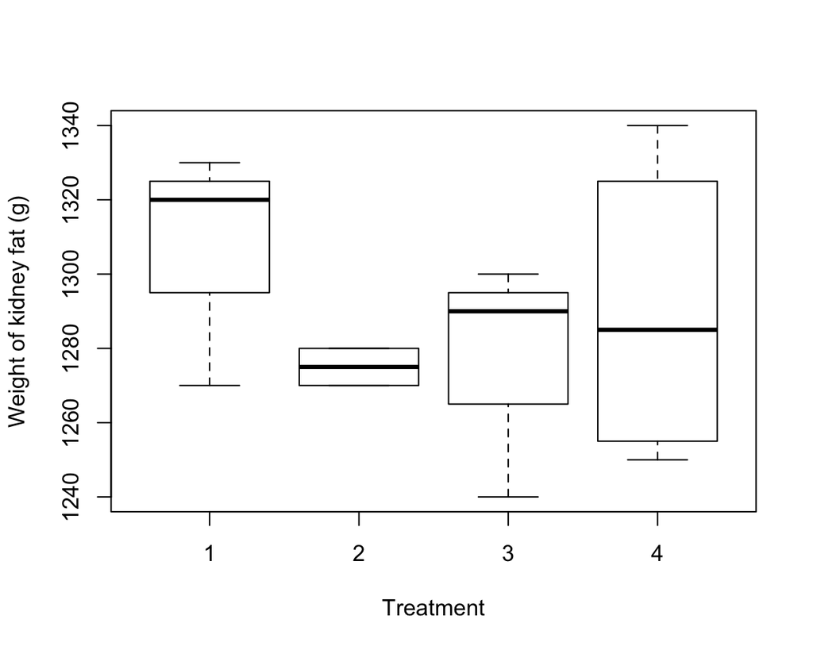

```r
plot(steers$y ~ steers$treat,cex=2
,xlab="Treatment",ylab="Weight of kidney fat (g)")
```

# 1-sidet ANOVA

### Uden justering for kropsvægt

Hvis man ønsker at undersøge, om hormonbehandlingen (**treat**) har indflydelse på mængden af nyrefedt (**y**) er det fristende blot at lave en ensidet variansanalysemodel.

Test for effekt af hormonbehandlingen

```r
model3 <- lm(y ~ treat, data = steers)
model4 <- lm(y ~ 1, data = steers)
anova(model4, model3)
```

```
Analysis of Variance Table

Model 1: y ~ 1
Model 2: y ~ treat
  Res.Df   RSS Df Sum of Sq      F Pr(>F)
1     15 12775
2     12  9900  3      2875 1.1616 0.3647
```

Konklusion: Ingen effekt af hormonbehandlingen (F=1.162, p=0.365).

### Med justering for kropsvægt

Nedenfor udføres et test for effekten af hormonbehandlingen på mængden af nyrefedt, når vi samtidig justerer for kropsvægten. Rent praktisk tester vi for effekt af **treat** i en model, hvor vi samtidig inddrager kropsvægten (**x**) som en kovariat i modellen.

```r
model1 <- lm(y ~ treat + x, data = steers)
model2 <- lm(y ~ x, data = steers)
anova(model2, model1)
```

```
Analysis of Variance Table

Model 1: y ~ x
Model 2: y ~ treat + x
  Res.Df    RSS Df Sum of Sq      F   Pr(>F)
1     14 3800.7
2     11 1387.2  3    2413.5 6.3794 0.009175 **
---
Signif. codes:  0 '***' 0.001 '**' 0.01 '*' 0.05 '.' 0.1 ' ' 1
```

Konklusion: Signifikant effekt af hormonbehandlingen (F=6.379, p=0.009).

### Diskussion

Når man udfører et test for en hypotese i en lineær normal model (dvs. modeller fittet med lm()-funktionen i R), så sammenligner man mængden af uforklaret variation ved de to modeller. Mængden af uforklaret variation (kan) måles ved *residual sum of squares* (RSS eller SSe), som kan udtrækkes i R ved brug af funktionen **deviance()**. Desuden er det for at konstruere F-teststørrelsen nødvendigt at kende antallet af frihedsgrader for modellen. Bemærk, at der opereres med forskellige begreber:

- model degrees of freedom (**df**): angiver antallet af parametre i middelværdistrukturen og kan f.x. findes ved at se på, hvor mange estimater der kommer ud, når man skriver **summary(model)**
- error degrees of freedom (**edf**): angiver forskellen mellem antallet af observationer og *model degrees of freedom* (dvs **edf** = N - **df** )

Nedenfor udtrækkes *residual sum of squares* for de forskellige modeller

```r
deviance(model1); deviance(model2); deviance(model3); deviance(model4)
```

```
[1] 1387.183
```

```
[1] 3800.668
```

```
[1] 9900
```

```
[1] 12775
```

Når vi *ikke* inddrager kovariaten kropsvægt (**x**) i modellen, så er der er meget stor uforklaret variation (dvs. stor RSS). Derfor bliver det svært at detektere en effekt af hormonbehandlingen **treat**.

Nedenfor vises, hvordan F-teststørrelsen for test af *model2* mod *model1* kan konstrueres manuelt ud fra modellerne

```r
F_taeller <- (deviance(model2) - deviance(model1)) / (model2$df.residual - model1$df.residual)
F_naevner <- deviance(model1) / model1$df.residual
F <- F_taeller / F_naevner
F
```

```
[1] 6.379438
```

```r
p_value <- 1 - pf(F, df1 = model2$df.residual - model1$df.residual, df2 = model1$df.residual)
p_value
```

```
[1] 0.00917513
```

# Estimater

### Standardparametrisering

Med udgangspunkt i *model1* (1-sidet ANOVA justeret for kovariaten **x**) kan man *ikke* se bort fra effekt af hormonbehandlingen **treat**.

```r
summary(model1)
```

```
Call:
lm(formula = y ~ treat + x, data = steers)

Residuals:
    Min      1Q  Median      3Q     Max
-15.349  -6.661  -2.535   6.337  16.364

Coefficients:
             Estimate Std. Error t value Pr(>|t|)
(Intercept) 1150.5901    20.1982  56.965 6.02e-15 ***
treat2       -15.2792     8.2955  -1.842  0.09259 .
treat3       -28.3566     7.9432  -3.570  0.00440 **
treat4       -31.5038     8.0631  -3.907  0.00245 **
x              0.3287     0.0400   8.216 5.07e-06 ***
---
Signif. codes:  0 '***' 0.001 '**' 0.01 '*' 0.05 '.' 0.1 ' ' 1

Residual standard error: 11.23 on 11 degrees of freedom
Multiple R-squared:  0.8914,    Adjusted R-squared:  0.8519
F-statistic: 22.58 on 4 and 11 DF,  p-value: 2.936e-05
```

```r
confint(model1)
```

```
                   2.5 %       97.5 %
(Intercept) 1106.1340676 1195.0461355
treat2       -33.5374202    2.9790445
treat3       -45.8393733  -10.8738246
treat4       -49.2506534  -13.7569608
x              0.2406312    0.4167292
```

Vi ser desuden af output, at koefficienten til **x** estimeres til 0.329 [95 % KI: 0.241-0.417]. Da konfidensintervallet ikke indeholder 0, så bidrager **x** signifikant til at forklare variationen i mængden af nyrefedt (**y**), hvilket bekræftes af at p-værdien er (meget) mindre en 0.05.

### Parametrisering uden intercept

Vi kan omparametrisere modellen, så estimaterne bliver lettere fortolkelige …

```r
model1alt <- lm(y ~ x + treat - 1, data = steers)
summary(model1alt)
```

```
Call:
lm(formula = y ~ x + treat - 1, data = steers)

Residuals:
    Min      1Q  Median      3Q     Max
-15.349  -6.661  -2.535   6.337  16.364

Coefficients:
        Estimate Std. Error t value Pr(>|t|)
x         0.3287     0.0400   8.216 5.07e-06 ***
treat1 1150.5901    20.1982  56.965 6.02e-15 ***
treat2 1135.3109    17.9050  63.407 1.86e-15 ***
treat3 1122.2335    20.0062  56.094 7.13e-15 ***
treat4 1119.0863    21.5467  51.938 1.66e-14 ***
---
Signif. codes:  0 '***' 0.001 '**' 0.01 '*' 0.05 '.' 0.1 ' ' 1

Residual standard error: 11.23 on 11 degrees of freedom
Multiple R-squared:  0.9999,    Adjusted R-squared:  0.9999
F-statistic: 4.216e+04 on 5 and 11 DF,  p-value: < 2.2e-16
```

### Adjusted means

Den gennemsnitlige vægt af alle stude i datasættet er 477.5. Vi kan udtrække forventede / prædikterede værdier af mængden af nyrefedt for hver af de 4 hormonbehandlinger for en gennemsnits-stud ved brug af **estimable**. Disse størrelser omtales ofte som **adjusted means** for behandlingsfaktoren **treat**

```r
library(gmodels)
xbar <- mean(steers$x) ### gnsn. af begyndelsesvaegt!
adj.m1 <- c(xbar, 1, 0, 0, 0)
adj.m2 <- c(xbar, 0, 1, 0, 0)
adj.m3 <- c(xbar, 0, 0, 1, 0)
adj.m4 <- c(xbar, 0, 0, 0, 1)
adj.means <- rbind(adj.m1, adj.m2, adj.m3, adj.m4)
estimable(model1alt, adj.means, conf.int = 0.95)
```

```
       Estimate Std. Error  t value DF Pr(>|t|) Lower.CI Upper.CI
adj.m1 1307.535   5.622891 232.5378 11        0 1295.159 1319.911
adj.m2 1292.256   5.994818 215.5621 11        0 1279.061 1305.450
adj.m3 1279.178   5.615771 227.7832 11        0 1266.818 1291.539
adj.m4 1276.031   5.866644 217.5061 11        0 1263.119 1288.943
```